# PADP8120 Midterm Fall 2015

Jonathan Parisi

# Midterm Exam

**due by class time (3:35) on October 14, 2015**

## Instructions

A. Fork the [Midterm repository](https://github.com/PADP8120-Fall2015/Midterm) from the course github page to your github account (i.e., just as you would with a homework assignment)

B. In RStudio, create a new project and link it to your newly forked github repo.

C. Resave the `Midterm_Fall2015.Rmd` file as `Midterm_Fall2015_FirstInitialLastName.Rmd` (e.g., `Midterm_Fall2015_TScott.Rmd`)

D. Complete the midterm within your `Midterm_Fall2015_FirstInitialLastName.Rmd` file.

E. Make sure your final document renders as an `.html` file.

F. Please **email** to me all of the materials necessary for another person to run your R Markdown file, including: - The R project (`.Rproj`) file - The R Markdown document (`.Rmd`) of your analyses - An HTML document (`.html`) compiled from your R Markdown document. - Any data or other files neede to run the analyses in your R Markdown document.

## Guidelines

1. This is a take-home, open-book exam. This means that you are welcome to use any resources at your disposal–including textbooks, R help files, and internet resources–EXCEPTING other students (see Guideline #2).
2. However, you are expected to work alone, meaning that this exam **must not** be done as a group project or in concert with your classmates (or with the assistant of other SPIA students/faculty). The work you submit is to be yours and yours alone.
3. Your exam write-up should be clear and legible, with answers clearly indicated and work shown. Your exam must be produced in html (.html) document produced using R Markdown (i.e., an .Rmd file). Submit both your .html file and the .Rmd file used to generate it via github to the course midterm repo. If you are having trouble accomplishing this, please refer to the [guide](http://spia.uga.edu/faculty_pages/tyler.scott/teaching/PADP8120_Fall2015/Homeworks/submitting_homework.shtml).
4. The exam will be graded out of 100 points. Each problem is worth a designated number of points (shown below). Partial credit *may* by given for incorrect answers if I am able to see the process by which you went wrong (and thus see what you also did correctly), so it is to your advantage to show your work.
5. Your exam is **due by class time (3:35) on October 14, 2015**
6. Please contact me if you have any questions or concerns.

# Problems

You are asked to analyze data from a New York City school voucher experiment that a colleague and I obtained from Mathematica for a paper.

```r
library(dplyr)
```

```r
nyc = read.csv('input/NYC_SchoolVoucher_Experiment.csv',row.names=1)
```

Most of the variables you need should be pretty self explanatory:

| Variable | Description |
| --- | --- |
| `Student_ID` | numerical code for each student |
| `Family_ID` | numerical code for each family |
| `Date.Of.Birth` | student birthday |
| `Female` | binary indicator for female students |
| `Grade` | student grade level when starting experiment |
| `Treatment` | binary indicator for whether student received voucher |
| `Latino` | binary indicator for Latino students |
| `Black` | binary indicator for black students |
| `Eldest` | binary indicator for eldest children |
| `y0_read_percentile` | pre-test reading score percentile |
| `y0_math_percentile` | pre-test math score percentile |
| `y1_read_percentile` | reading score percentile after 1y |
| `y1_math_percentile` | math score percentile after 1y |
| `y2_read_percentile` | reading score percentile after 2y |
| `y2_math_percentile` | math score percentile after 2y |
| `y3_read_percentile` | reading score percentile after 3y |
| `y3_math_percentile` | math score percentile after 3y |

1. (6 points) Compute the average reading and math percentiles for each year across all students.

The mean scores (among reported values) are as follows:

```r
summarise(nyc,mean(y0_read_percentile, na.rm=TRUE))
```

```
##   mean(y0_read_percentile, na.rm = TRUE)
## 1                               22.78282
```

```r
summarise(nyc,mean(y0_math_percentile, na.rm=TRUE))
```

```
##   mean(y0_math_percentile, na.rm = TRUE)
## 1                               16.54241
```

```r
summarise(nyc,mean(y1_read_percentile, na.rm=TRUE))
```

```
##   mean(y1_read_percentile, na.rm = TRUE)
## 1                               26.05625
```

```r
summarise(nyc,mean(y1_math_percentile, na.rm=TRUE))
```

```
##   mean(y1_math_percentile, na.rm = TRUE)
## 1                               22.29663
```

```r
summarise(nyc,mean(y2_read_percentile, na.rm=TRUE))
```

```
##   mean(y2_read_percentile, na.rm = TRUE)
## 1                               26.09179
```

```r
summarise(nyc,mean(y2_math_percentile, na.rm=TRUE))
```

```
##   mean(y2_math_percentile, na.rm = TRUE)
## 1                               23.55872
```

```r
summarise(nyc,mean(y3_read_percentile, na.rm=TRUE))
```

```
##   mean(y3_read_percentile, na.rm = TRUE)
## 1                               32.63465
```

```r
summarise(nyc,mean(y3_math_percentile, na.rm=TRUE))
```

```
##   mean(y3_math_percentile, na.rm = TRUE)
## 1                               32.50139
```

Note: I tried to use a loop for that, but the nyc[10] notation wouldn’t work in the summarise function.

2. (4 points) Clean the original dataset by removing all students who do not have observe pre-test scores and year 1 scores for reading and for math.

```r
cleandata1<-filter(nyc, !is.na(y0_read_percentile))
cleandata2<-filter(cleandata1, !is.na(y0_math_percentile))
cleandata3<-filter(cleandata2, !is.na(y1_read_percentile))
cleandata4<-filter(cleandata3, !is.na(y1_math_percentile))
```

3. (8 points) Make a figure (either a density plot of a histgram format) comparing the distributions of percentile reading scores for students who did and did not receive a voucher. Do your best to make the figure “publishable” by giving it clear axis titles, legend labels, and other aesthetic improvements.

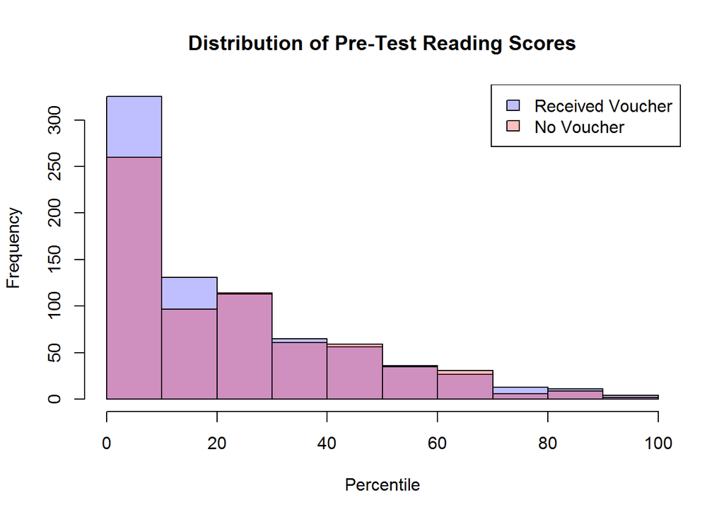

```r
plot(p1, main="Distribution of Pre-Test Reading Scores", xlab="Percentile", col=rgb(0,0,1,1/4))
plot(p2, col=rgb(1,0,0,1/4), add=T)
legend("topright",c("Received Voucher", "No Voucher"), fill=c(rgb(0,0,1,1/4),rgb(1,0,0,1/4)))
```

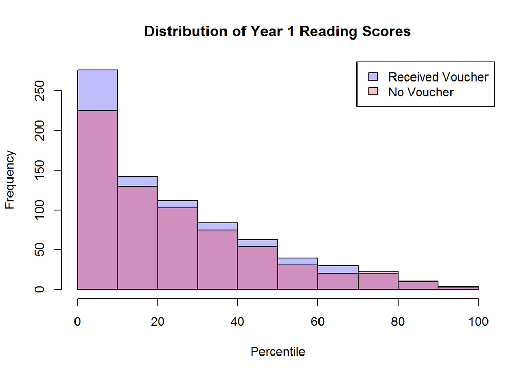

```r
plot(p1, main="Distribution of Year 1 Reading Scores", xlab="Percentile", col=rgb(0,0,1,1/4))
plot(p2, col=rgb(1,0,0,1/4), add=T)
legend("topright",c("Received Voucher", "No Voucher"), fill=c(rgb(0,0,1,1/4),rgb(1,0,0,1/4)))
```

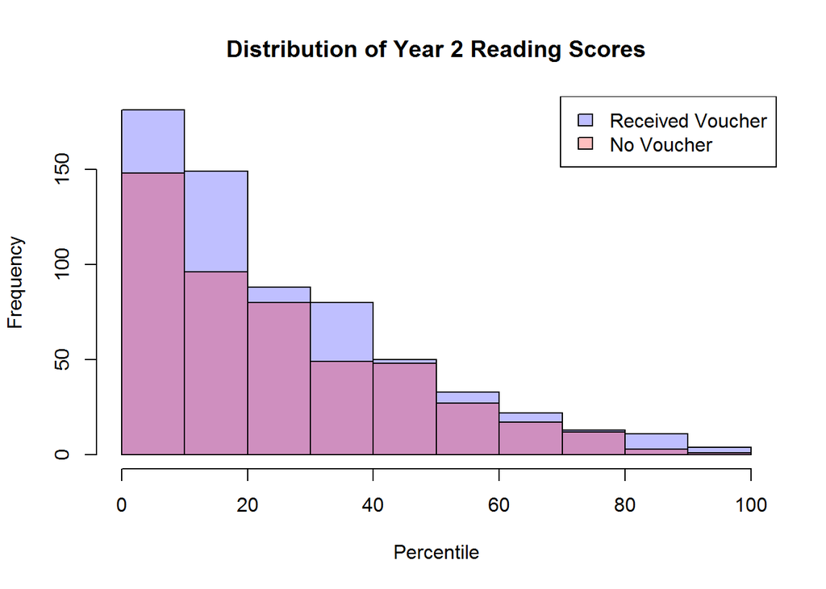

```r
plot(p1, main="Distribution of Year 2 Reading Scores", xlab="Percentile", col=rgb(0,0,1,1/4))
plot(p2, col=rgb(1,0,0,1/4), add=T)
legend("topright",c("Received Voucher", "No Voucher"), fill=c(rgb(0,0,1,1/4),rgb(1,0,0,1/4)))
```

Now we look at Year 3:

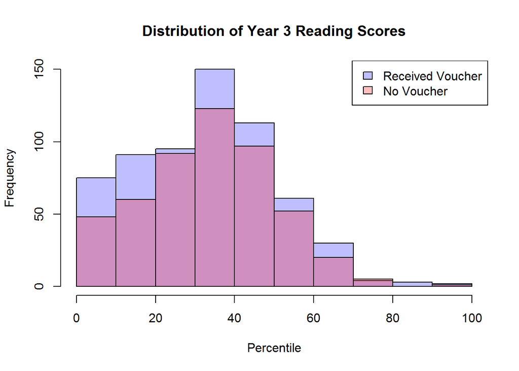

```r
plot(p1, main="Distribution of Year 3 Reading Scores", xlab="Percentile", col=rgb(0,0,1,1/4))
plot(p2, col=rgb(1,0,0,1/4), add=T)
legend("topright",c("Received Voucher", "No Voucher"), fill=c(rgb(0,0,1,1/4),rgb(1,0,0,1/4)))
```

4. (4 points) In no more than 2-3 sentences, describe what your visualization in 1.C indicates about these data. Do the treatment and control groups appear to be similar (in terms of reading pre-test scores)? Why or why not?

The fact that there are more students in the Treatment group needs to be taken into consideration when viewing the histograms. However, accounting for sample size, the distributions appear to share a very similar shape. Therefore there is reason to believe that the assignment to treatment and control groups was random.

5. (4 points) Typically, policy experiments such as the NYC school voucher lottery experiment are indended to produce statistical evidence that can then be generalized to broader policy applications (i.e., how might vouchers influence educational outcomes for other students who weren’t part of the original experiment). Based on the reading pre-test scores that you visualized in C, describe any concerns you might have about our ability to generalize the results of this experiment to ALL elementary school students in the United States in no more than 2-3 sentences.

The bulk of the scores in this sample is concentrated in the lowest quartile for all students (presumably in the US). The overall average among elementary students should be centered around the 50th percentile, assuming an approximately normal distribution. Therefore, this is not likely a representative sample.

6. (4 points) What is the probability that a randomly selected student in the dataset received a voucher and scored above the 50th percentile on the math pre-test?

```r
sum(Trt$y0_math_percentile>50)/nrow(cleandata4)
```

```
## [1] 0.03642612
```

The probability that a randomly selected student in the dataset received a voucher and scored above the 50th percentile on the math pre-test is 0.036.

The call to sum(Trt$y0_math_percentile>50) gives the total number of desired observations and nrow(cleandata4) is the overall sample size (voucher and non-voucher).

7. (4 points) What is the probability that a randomly selected student who received a voucher group scored above the 50th percentile on the math pre-test?

```r
sum(Trt$y0_math_percentile>50)/nrow(Trt)
```

```
## [1] 0.06786172
```

The probability that a randomly selected student who received a voucher group scored above the 50th percentile on the math pre-test is 0.068. In this case the sample size or denominator is is the group of students receiving a voucher only.

8. (4 points) We are interested in studying whether the change in math scores after one year is different for students who receive a voucher versus those who do not. Write the null and alternative hypotheses in words and then using symbols.

Null: After one year, the change in math scores for students receiving a voucher (Treatment) will be no different from those not receiving a voucher (Control).

Alternative: After one year, the change in math scores for students receiving a voucher (Treatment) will be different from those not receiving a voucher (Control).

With “mu” representing the average change in test scores for each group:

$H_0: \mu_T - \mu_C = 0$ $H_A: \mu_T - \mu_C != 0$

9. (6 points) Evaluate the hypothesis from 1.H at a significance level of $\alpha = 0.05$ and state your conclusion in 1-2 sentences.

```r
Tdiff<-Trt$y1_math_percentile-Trt$y0_math_percentile
Cdiff<-Ctrl$y1_math_percentile-Ctrl$y0_math_percentile
t.test(Tdiff, Cdiff,alternative="two.sided")
```

```
##
##  Welch Two Sample t-test
##
## data:  Tdiff and Cdiff
## t = 0.5829, df = 1385.502, p-value = 0.5601
## alternative hypothesis: true difference in means is not equal to 0
## 95 percent confidence interval:
##  -1.462600  2.699293
## sample estimates:
## mean of x mean of y
##  7.104994  6.486647
```

There is insufficient evidence that the receipt of a voucher results in a change in math test scores after one year.

10. (2 points) Would your conclusion change at $\alpha = 0.10$? Why or why not?

No, because the p-value for the test was 0.56, which is greater than 0.10.

11. (6 points) There are four assumptions that hold for the test above to be valid: independence within groups, independence between groups, sample sizes both above 30, and symmetric distributions. Are you satisfied that each of these are upheld? Is there anything in particular that you might be concerned about?

The assumption of independence within groups appears justified, since there is no reason to believe the test scores of any one student in either group would have an effect on another student in that group.

Likewise, there is no reason to believe the test scores of any one student in either group would have an effect on a student in the other group, so independence between groups seems satisfied.

The sample sizes are both well above 30.

Finally, there may be cause for concern with respect to the assumption of symmetric distributions. Using the mean calculated in problem 1 and the histogram from problem 3, it appears that for year 1 the bulk of the data is not concentrated at the mean, a key feature of symmetric distributions. Additionally, the mean year 1 math score of 22.29 is well above the median of 15, and the distributions of both groups are right-skewed.

```r
summarise(nyc,mean(y0_math_percentile, na.rm=TRUE))
```

```
##   mean(y0_math_percentile, na.rm = TRUE)
## 1                               16.54241
```

```r
summarise(nyc,median(y1_math_percentile, na.rm=TRUE))
```

```
##   median(y1_math_percentile, na.rm = TR...
## 1                                       15
```

12. (4 points) Next, you are asked to evaluate whether students in the treatment group differ in terms of their reading ability from the pre-test to the year 1 post-test. Write out the null and alternative hypotheses in words and then in symbols.

Null: After one year, the average reading percentile among students receiving a voucher (Treatment) will be no different than in the Pre-test.

Alternative: After one year, the average reading percentile among students receiving a voucher (Treatment) will be different than in the Pre-test.

With “mu” representing the average test score for each group:

$H_0: \mu_1 - \mu_0 = 0$ $H_A: \mu_1 - \mu_0 != 0$

13. (6 points) Conduct a t-test to evaluate this hypothesis at $\alpha = 0.01$ significance level. Interpret your results in 1-2 complete sentences.

```r
Tdiff<-Trt$y1_read_percentile-Trt$y0_read_percentile
t.test(Tdiff,alternative="two.sided", conf.level=.99)
```

```
##
##  One Sample t-test
##
## data:  Tdiff
## t = 3.9313, df = 780, p-value = 9.199e-05
## alternative hypothesis: true mean is not equal to 0
## 99 percent confidence interval:
##  0.9425593 4.5503984
## sample estimates:
## mean of x
##  2.746479
```

Based on the p-value below 0.005 in the test above, we can conclude with 99% confidence that the average reading score percentile in the Treatment group has changed over the 1st year.

14. (4 points) Explain how you could evaluate the hypothesis above using a confidence interval instead of a p-value.

The data being tested represents for each observation the difference between percentile score at year 1 vs year 0 (i.e. year 1 score - year 0 score). The t-test evaluates whether the population mean (score difference) is equal to zero based on our sample data, and provides a confidence interval for an estimate of the population mean. The confidence interval provided by R gives a range of 0.94 to 4.55, with a specified confidence level of 99%. Since 0 does not fall within the confidence interval, we can conclude with 99% confidence that the scores have changed (i.e. the mean change in score is different from 0).

15. (2 points) Interpret the confidence interval you estimated for question N in a sentence.

We are 99% confident that the mean change in reading percentile among the Treatment group students from the pre-test to year 1 scores is between 0.94 and 4.55 percentage points.

16. (8 points) Perform a test of whether the average math pre-test score differs by grade level at $\alpha = 0.10$ significance level. Write out your hypothesis in symbols, perform the test, and then report your findings in a complete sentence.

First, let’s have a look at the data:

```r
summarise(group_by(cleandata4, Grade),mean(y0_math_percentile, na.rm=TRUE))
```

```
## Source: local data frame [8 x 2]
##
##   Grade mean(y0_math_percentile, na.rm = TRUE)
## 1    -7                               15.62500
## 2     0                                3.00000
## 3     1                               10.83429
## 4     2                               18.94960
## 5     3                               16.15040
## 6     4                               20.74286
## 7     5                               29.75000
## 8    NA                               13.71053
```

```r
unique(cleandata4$Grade)
```

```
## [1]  3  2  4  1 -7 NA  0  5
```

```r
cleandata5<-filter(cleandata4,Grade!="0", Grade!="-7", !is.na(Grade))
```

Since grade -7 makes no sense, we will drop these records, as well as those with grade = NA and grade = 0 (only 3 observations for grade =0). We can then use an ANOVA test to answer this question, testing whether any of the means (pre-test scores by grade) are different or if all are the same. The null hypothesis is that all the means are the same.

$H_0: \mu_1 = \mu_2 = \mu_3 = \mu_4 = \mu_5$

$H_A:$ At least one of the means is different

```r
summary(aov(cleandata5$y0_math_percentile~as.character(cleandata5$Grade)))
```

```
##                                  Df Sum Sq Mean Sq F value   Pr(>F)
## as.character(cleandata5$Grade)    4  19285    4821    13.5 8.53e-11 ***
## Residuals                      1385 494739     357
## ---
## Signif. codes:  0 '***' 0.001 '**' 0.01 '*' 0.05 '.' 0.1 ' ' 1
```

We compare our p-value from the F-test to the 0.10 alpha level and determine that we have strong evidence to conclude that pre-test math scores did differ by grade.

17. (8 points) The NYC School District considers students who perform at or above the 50th percentile to be “passing”. At a 99% significance level, is the proportion of all students in the sample (voucher and no-voucher) that are considered to be passing in math significantly different between the pre-test and year 1 post-test?

```r
n1<-nrow(cleandata4)
p1<-(sum(cleandata4$y1_math_percentile>=50))/nrow(cleandata4)
p0<-(sum(cleandata4$y0_math_percentile>=50))/nrow(cleandata4)
prop.test(c(n1*p1,n1*p0), c(n1,n1), alternative="two.sided", conf.level=.99)
```

```
##
##  2-sample test for equality of proportions with continuity
##  correction
##
## data:  c(n1 * p1, n1 * p0) out of c(n1, n1)
## X-squared = 30.3675, df = 1, p-value = 3.575e-08
## alternative hypothesis: two.sided
## 99 percent confidence interval:
##  0.03420052 0.09500910
## sample estimates:
##     prop 1     prop 2
## 0.14226804 0.07766323
```

Based on our p-value below 0.005 we can conclude with 99% confidence that the proportion of all students in the sample (voucher and no-voucher) that are considered to be passing in math is significantly different between the pre-test and year 1 post-test. Note that since we cleaned the data so that all students have Y0 and Y1 reading and math scores, both proportions are based on the number of students in the cleaned sample (n1= n2).

18. (6 points) Make a boxplot that compares the distribution of math scores between the pre-test and year 1 post-test for all students. Do your best to make the figure “publishable” by giving it clear axis titles, legend labels, and other aesthetic improvements. In no more than 2-3 sentences, describe how your figure supports (or does not support) your finding from question 17.

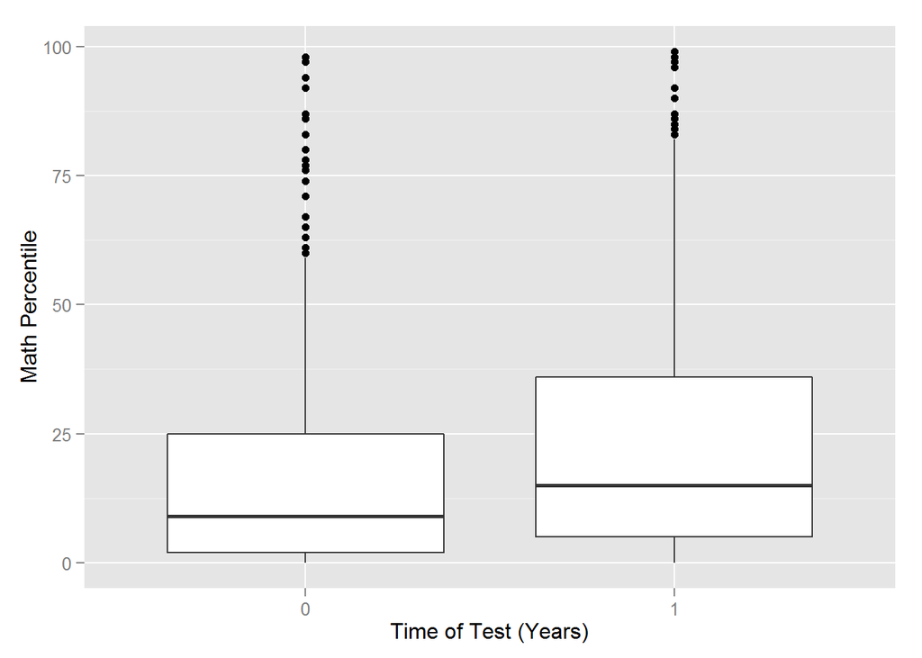

```r
library(ggplot2)

students<-c(cleandata4$Student_ID, cleandata4$Student_ID)
percentile<-c(cleandata4$y0_math_percentile, cleandata4$y1_math_percentile)
testyear<-as.factor(c(rep(0, 1455), rep(1,1455)))
boxdata<-data.frame(students, testyear, percentile)
ggplot(boxdata,aes(x=as.factor(testyear),y=percentile)) + geom_boxplot() +xlab("Time of Test (Years)") +ylab("Math Percentile")
```

The box plot is not the best visualization to address question #17, as the passing mark of 50% is well into the upper quartile of the data. However, the plot does show improvement in scores from pre-test to the year 1 test. Also, fewer of the passing scores are plotted as outliers.

19. (4 points) Consider the correlation between math percentile and reading percentile for year 1 test scores. Compute Pearson’s `r` between these two variables. Is the correlation higher or lower than you would have expected?

```r
cor(x=cleandata4$y1_read_percentile, y=cleandata4$y1_math_percentile, method="pearson")
```

```
## [1] 0.6164846
```

The correlation of roughly 0.62 is perhaps slightly lower than I would have expected, as the intelligence and family educational stewardship of each child should have strong effects on both scores for each student. However, the magnitude of the correlation is not altogether surprising, since students have different aptitudes for reading and math.

20. (6 points) You might argue that percentiles are actually rank-order data and not ratio-level data. For rank-order data, a more appropriate correlation measure is Spearman’s $\rho$, which is a rank correlation. Compute $\rho$ and contrast the results from $r$ (for question S above). Why do the results differ?

```r
cor(x=cleandata4$y1_read_percentile, y=cleandata4$y1_math_percentile, method="spearman")
```

```
## [1] 0.5848958
```

The Spearman coefficient is approximately 0.58. The results differ because the Pearson coefficient is testing the linear relationship between the test scores, while the Spearman coefficient is testing the relationship between the rank ordered test scores in each group.